# Predicting House Prices

Alberto Lombatti

5/21/2019

### Libraries used

These are the libraries I have used in order to complete the project

```r
library(ggplot2)
library(corrplot)
library(Stack)
library(fastDummies)
library(dplyr)
```

### Import the data

The data is uploaded on a gist, and we store it in two data.frame objects called *train* and *test*

```r
train <- read.csv("https://gist.githubusercontent.com/alombatti/f2cb8f1a244784999353309a97a6777f/raw/f38ee90641da97f62964ac10ea558564bfc6cb65/house_price_train.csv")
```

```r
test <- read.csv("https://gist.githubusercontent.com/alombatti/1df87e336f159842e64ced9380b13e25/raw/49ea0fe6b42fb5d4868e1291dc8e47b20d2cc3bd/house_price_test.csv")
```

## Data understanding

This dataset contains house sale prices for King County, which includes Seattle, Washington. It includes homes sold between May 2014 and May 2015. The dataset provided to us has already been devided in train set and test set, in the sizes of 17277 observations for the train and 4320 observations for the test.

The fields describing the data are:

1. **id**: a notation for a house
2. **date**: the date the house was sold
3. **price**: the prediction target, consisting in the amount in US Dollars the house was sold at
4. **bedrooms**: the number of bedrooms in the house
5. **bathrooms**: the number of bathrooms in the house
6. **sqft_living**: square footage of the home
7. **sqft_lot**: square footage of the lot
8. **floors**: total floors (levels) in the house
9. **waterfront**: use which has a view to the waterfront
10. **view**: how many times the house has been viewed
11. **condition**: overall condition of the house
12. **grade**: overall grade given to the housing unit, based on King County grading system
13. **sqft_above**: square footage of house apart from basement
14. **sqft_basement**: square footage of the basement
15. _**yr_built**: the year in which the house was completed
16. **yr_renovated**: year when house was renovated
17. **zipcode**: zip
18. **lat**: latitude coordinate
19. **long**: longitude coordinate
20. **sqft_living15**: living room area in 2015 (if different fron sqft_living, it implies some renovations)
21. **sqft_lot15**: lot area in 2015 (if different from sqft_lot, it implies some renovations)

Here is a glimpse of what the **STRUCTURE** of the data looks like (for the train set)

```r
str(train)
```

```
## 'data.frame':    17277 obs. of  21 variables:
##  $ id           : num  9.18e+09 4.64e+08 2.22e+09 6.16e+09 6.39e+09 ...
##  $ date         : Factor w/ 372 levels "1/10/2015","1/12/2015",..: 211 331 290 20 226 223 94 34 76 294 ...
##  $ price        : num  225000 641250 810000 330000 530000 ...
##  $ bedrooms     : int  3 3 4 4 4 4 4 3 4 3 ...
##  $ bathrooms    : num  1.5 2.5 3.5 1.5 1.75 3.5 3.25 2.25 2.5 1.5 ...
##  $ sqft_living  : int  1250 2220 3980 1890 1814 3120 4160 1440 2250 2540 ...
##  $ sqft_lot     : int  7500 2550 209523 7540 5000 5086 47480 10500 6840 9520 ...
##  $ floors       : num  1 3 2 1 1 2 2 1 2 1 ...
##  $ waterfront   : int  0 0 0 0 0 0 0 0 0 0 ...
##  $ view         : int  0 2 2 0 0 0 0 0 0 0 ...
##  $ condition    : int  3 3 3 4 4 3 3 3 3 3 ...
##  $ grade        : int  7 10 9 7 7 9 10 8 9 8 ...
##  $ sqft_above   : int  1250 2220 3980 1890 944 2480 4160 1130 2250 1500 ...
##  $ sqft_basement: int  0 0 0 0 870 640 0 310 0 1040 ...
##  $ yr_built     : int  1967 1990 2006 1967 1951 2008 1995 1983 1987 1959 ...
##  $ yr_renovated : int  0 0 0 0 0 0 0 0 0 0 ...
##  $ zipcode      : int  98030 98117 98024 98155 98115 98115 98072 98023 98058 98115 ...
##  $ lat          : num  47.4 47.7 47.6 47.8 47.7 ...
##  $ long         : num  -122 -122 -122 -122 -122 ...
##  $ sqft_living15: int  1260 2200 2220 1890 1290 1880 3400 1510 2480 1870 ...
##  $ sqft_lot15   : int  7563 5610 65775 8515 5000 5092 40428 8125 7386 6800 ...
```

We then check for NAs in the data we are going to use, both in the train and in the test.

```r
print(length(which(is.na(train) == T)))
```

```
## [1] 0
```

```r
print(length(which(is.na(test) == T)))
```

```
## [1] 0
```

As we can see, the data does not contain any null values, so we can proceed with our analysis.

### Transformation of the DATE field

In order to analyze the field *DATE*, and to be able to determine whether it is relevant in our analysis, we have to transform it so that we can use it. I thought of separating the fields year, month, and day, to, further in the analysis, determine if any of them is directly correlated with the price.

First, I change the field *date* from factor to date, and I store in a new dataframe the complete field of the date, its year, its month, and its day. Then, I merge the newly created dataset with the one from which I extracted the date field, and I reorder the column in a way that makes sense for the analyais.

I repeat the same procedure for the *test* and the *train* datasets.

```r
train$date <- as.Date(train$date, "%m/%d/%Y")
df.date_train <- data.frame(date = train$date,
                      year = as.numeric(format(train$date, format = "%Y")),
                      month = as.numeric(format(train$date, format = "%m")),
                      day = as.numeric(format(train$date, format = "%d")))

train <- unique(merge(train, df.date_train))
rm(df.date_train)
train <- train[, c(2, 1, 22, 23, 24, 3:21)]
```

```r
test$date <- as.Date(test$date, "%m/%d/%Y")
df.date_test <- data.frame(date = test$date,
                           year = as.numeric(format(test$date, format = "%Y")),
                           month = as.numeric(format(test$date, format = "%m")),
                           day = as.numeric(format(test$date, format = "%d")))

test <- unique(merge(test, df.date_test))
rm(df.date_test)
test <- test[, c(2, 1, 21, 22, 23, 3:20)]
```

Now I stack together the train and test dataset to procede with a more accurate analysis. I also eliminate the field **id** and **date** because they are not going to be relevant.

```r
complete <- Stack(train, test)
complete$id = NULL
complete$date = NULL
```

The dataset now looks like this:

```r
head(complete)
```

```
##   year month day bedrooms bathrooms sqft_living sqft_lot floors waterfront
## 1 2014     5   2        3      2.50        1270     1180    3.0          0
## 2 2014     5   2        3      2.25        1970    35100    2.0          0
## 3 2014     5   2        3      2.50        2090    10834    1.0          0
## 4 2014     5   2        3      2.50        1770     1235    3.0          0
## 5 2014     5   2        3      3.00        1850    19966    1.0          0
## 6 2014     5   2        3      2.00        2710     4500    1.5          0
##   view condition grade sqft_above sqft_basement yr_built yr_renovated
## 1    0         3     8       1270             0     2001            0
## 2    0         4     9       1970             0     1977            0
## 3    0         4     8       1360           730     1987            0
## 4    0         3     8       1600           170     2007            0
## 5    0         4     7       1090           760     1992            0
## 6    0         4     8       1880           830     1929            0
##   zipcode     lat     long sqft_living15 sqft_lot15  price
## 1   98107 47.6697 -122.392          1320       1180 445700
## 2   98027 47.4635 -121.991          2340      35100 437500
## 3   98003 47.3537 -122.303          1750       8595 285000
## 4   98103 47.6965 -122.342          1680       1203 436110
## 5   98038 47.3493 -122.034          1410       6715 287200
## 6   98115 47.6747 -122.295          2060       4500 805000
```

## Correlation matrix

Now I plot a correlation graph to see how much the different variables are correlated to our target variable *PRICE*

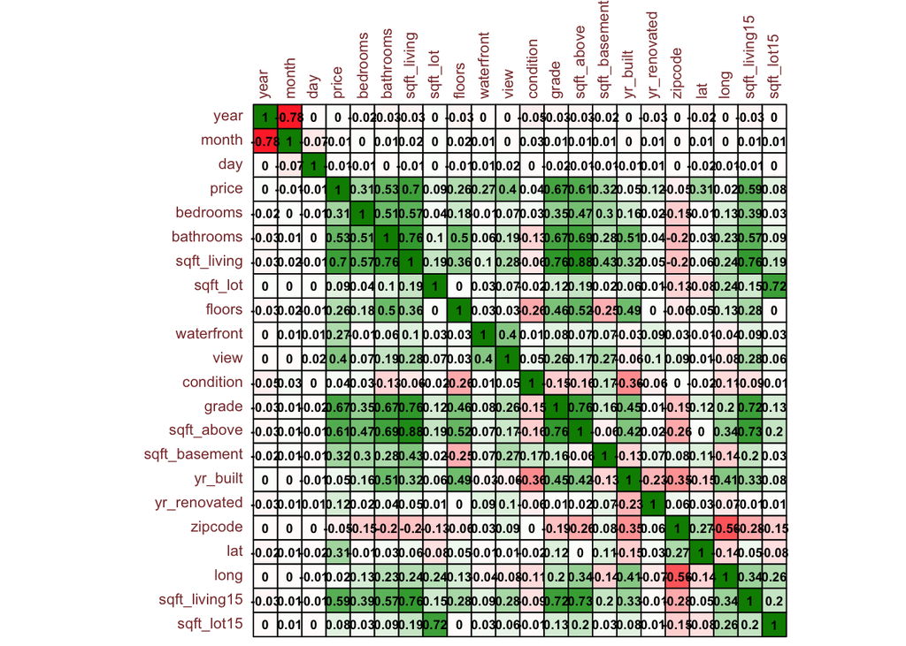

```r
corr = cor(train[, 3:24])

corrplot(corr, method = "color",
         outline = T,
         cl.pos = "n",
         rect.col = "black",
         tl.col = "indianred4",
         addCoef.col = "black",
         number.digits = 2,
         number.cex = 0.60,
         tl.cex = 0.7,
         cl.cex = 1,
         col = colorRampPalette(c("red", "white", "green4")) (100))
```

From the matrix, we can see that we have many variables correlated somehow with price, some more and some less. I decided to proceed my analysis keeoing only the variables that have a correlation >= 0.15 with the target variable.

Therefore, going forward I will only keep:

1. price
2. bedrooms
3. bathrooms
4. sqft_living
5. floors
6. waterfront
7. view
8. grade
9. sqft_above
10. sqft_basement
11. lat
12. sqft_living15

Nonetheless, some considerations have to be made. The variables **condition**, **yr_renovated**, and **zipcode** are going to be converted as factors further on in the analysis. Therefore, we still include them in the listof variables we are going to keep because we can not really interepret their value now since it is numeric, and as numeric it might not affect the correlation with *price*.

```r
complete2 <- select(complete, "price", "bedrooms", "bathrooms", "sqft_living", "floors",
                    "waterfront", "view", "grade", "sqft_above", "sqft_basement", "lat",
                    "sqft_living15", "condition", "yr_renovated", "zipcode")
```

## Data Visualization

In this section we are going to analyze the relationship of all the varaibles with our target, the variable *price*. Before doing this, I create a copy of the dataset, and I split it in *train* and *test*, based on the value of the variable price.

```r
complete2 <- complete

train2 <- split(complete2, complete2$price > 0)
train2 <- train2[["TRUE"]]

test2 <- split(complete2, is.na(complete2$price))
test2 <- test2[["TRUE"]]
```

### Distribution of prices

Here we look at the histrogram showing how many houses have been sold for each price.

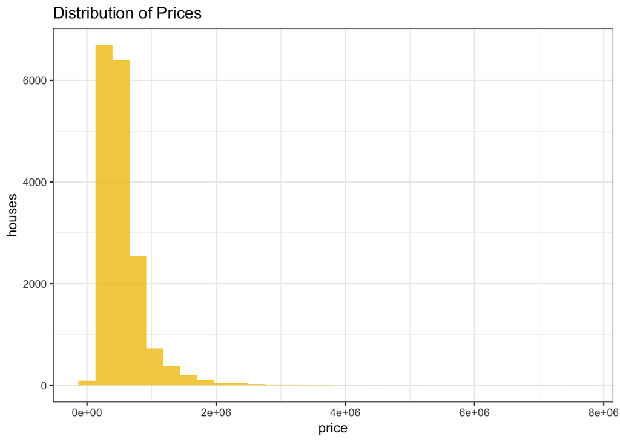

```r
graph1 <- ggplot(data = train2, aes(x = price)) +
  geom_histogram(alpha = 0.8, fill = "#F1C40F") +
  labs(x = "price", y = "houses", title = "Distribution of Prices") +
  theme_bw()

graph1
```

Since the interval of price of the houses is very wide, it is smart to focus only on a small segment, to see the patten where most of the houses are. In this histogram, we only see the distribution of houses sold at a price up to 1.5 million US Dollars.

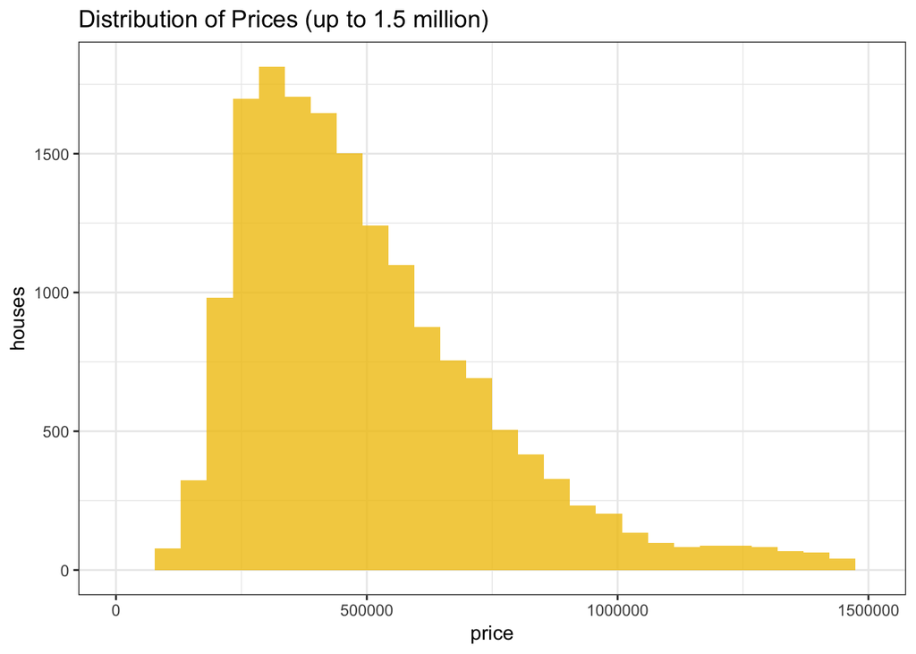

```r
graph2 <- ggplot(data = train2, aes(x = price)) +
  geom_histogram(alpha = 0.8, fill = "#F1C40F") +
  scale_x_continuous(limits=c(0, 1.5e6)) +
  labs(x = "price", y = "houses", title = "Distribution of Prices (up to 1.5 million)") +
  theme_bw()

graph2
```

For the sole purpose of data visualization, I now add a comuln to my *train* dataframe rapresenting the **logarithmic transformation** of the price, so that the graphs will look prettier and more understandable.

```r
train2$logprice = log(train2$price)
```

### Boxplot between price and bedrooms

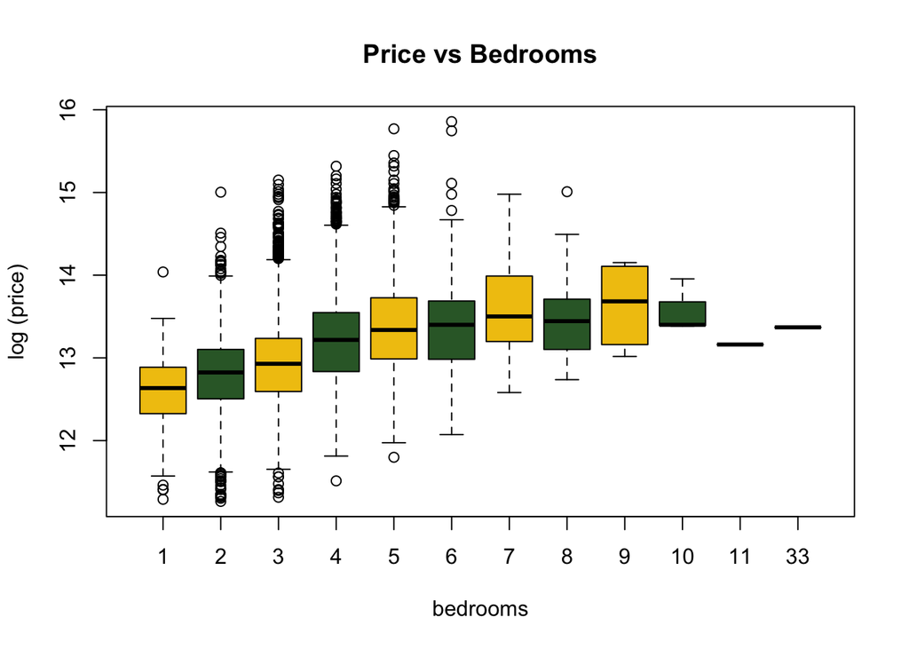

```r
graph3 <- boxplot(train2[, "logprice"] ~ train2[, "bedrooms"],
                  main = "Price vs Bedrooms", col=c("#F1C40F","#336633"),
                  xlab="bedrooms", ylab="log (price)")
```

From this graph, we notice there are two odd values, when the bedrooms are 11 and when the bedrooms are 33.

```r
print(subset(train2, train2$bedrooms > 10))
```

```
##      year month day bedrooms bathrooms sqft_living sqft_lot floors
## 2866 2014     6  25       33      1.75        1620     6000      1
## 6003 2014     8  21       11      3.00        3000     4960      2
##      waterfront view condition grade sqft_above sqft_basement yr_built
## 2866          0    0         5     7       1040           580     1947
## 6003          0    0         3     7       2400           600     1918
##      yr_renovated zipcode     lat     long sqft_living15 sqft_lot15  price
## 2866            0   98103 47.6878 -122.331          1330       4700 640000
## 6003         1999   98106 47.5560 -122.363          1420       4960 520000
##      logprice
## 2866 13.36922
## 6003 13.16158
```

In fact, we can see all the houses with a number of bedrooms bigger than 10 is just two, therefore we exclude these records from our analysis not to disturb our model.

### Boxplot between price and bathrooms

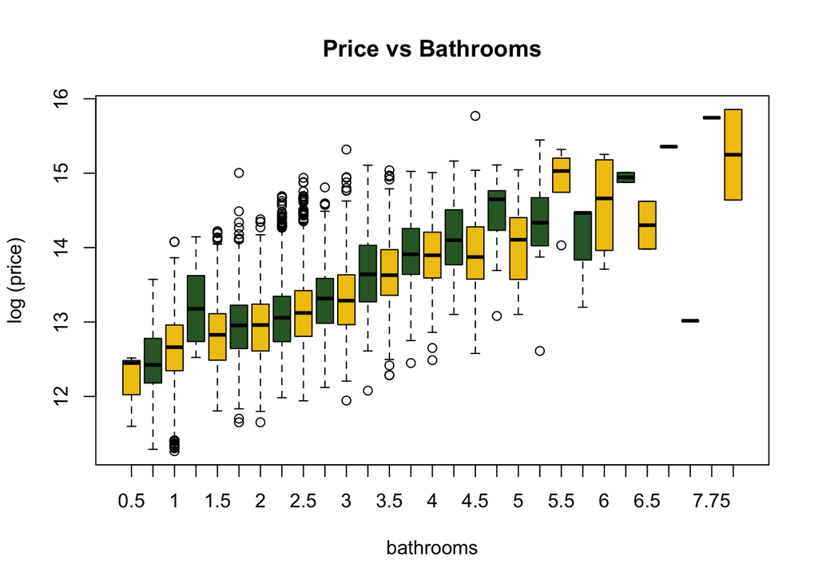

```r
graph4 <- boxplot(train2[, "logprice"] ~ train2[, "bathrooms"],
                  main = "Price vs Bathrooms", col=c("#F1C40F","#336633"),
                  xlab="bathrooms", ylab="log (price)")
```

The relationship looks linear overall. Nonetheless, the price of the house with 7.5 bathrooms is relatively lower than its neighbours. Therefore, we decide to eliminate that value.

### Boxplot between price and floors

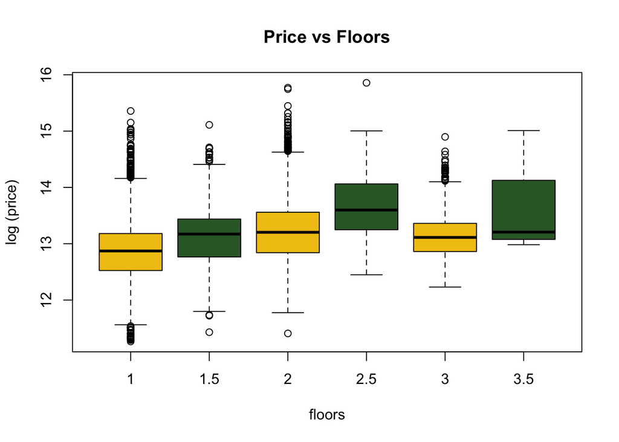

```r
graph5 <- boxplot(train2[, "logprice"] ~ train2[, "floors"],
                  main = "Price vs Floors", col=c("#F1C40F","#336633"),
                  xlab="floors", ylab="log (price)")
```

### Boxplot between price and waterfront

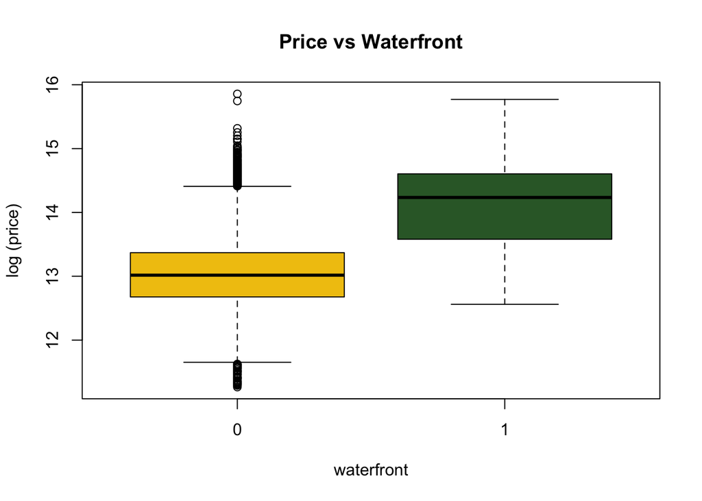

```r
graph6 <- boxplot(train2[, "logprice"] ~ train2[, "waterfront"],
                  main = "Price vs Waterfront", col=c("#F1C40F","#336633"),
                  xlab="waterfront", ylab="log (price)")
```

The relationsip is linear. Here, the 0 rapresents the houses without a waterfront, while the value 1 rapresents the houses with a waterfront. It is common sense that, if the house has a waterfront, its price is higher.

### Boxplot between price and view

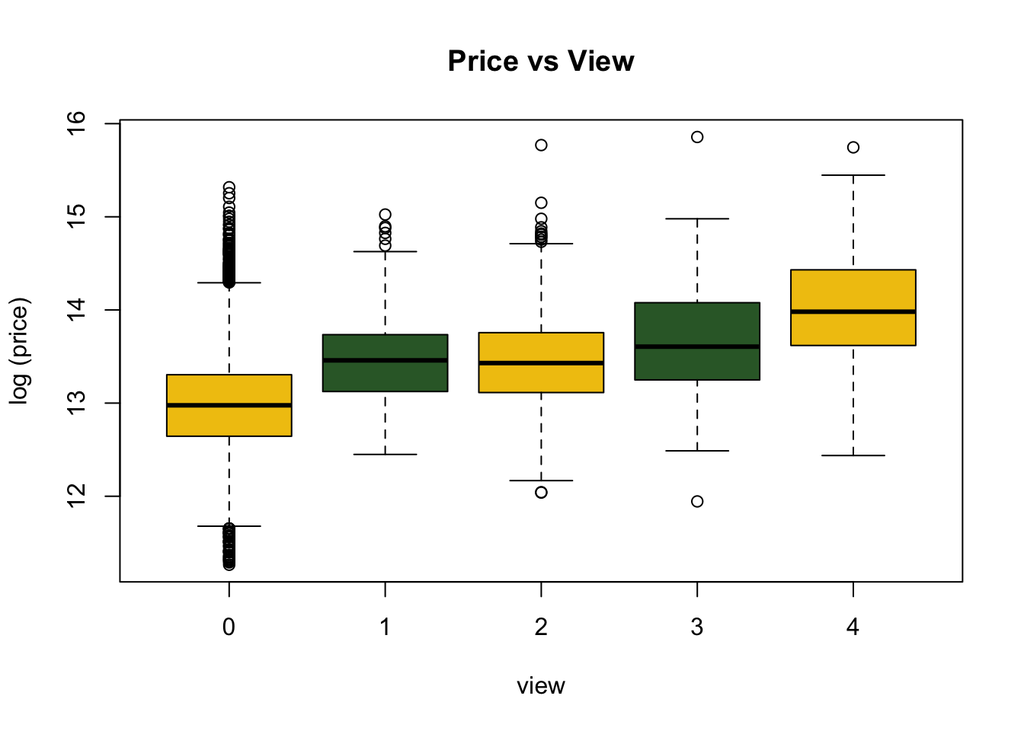

```r
graph7 <- boxplot(train2[, "logprice"] ~ train2[, "view"],
                  main = "Price vs View", col=c("#F1C40F","#336633"),
                  xlab="view", ylab="log (price)")
```

The relationsip is linear. Here, the 0 rapresents the worst view, while the value 4 rapresents the best view. It is common sense that, the more beautiful the view, the higher the price of the house.

### Boxplot between price and condition

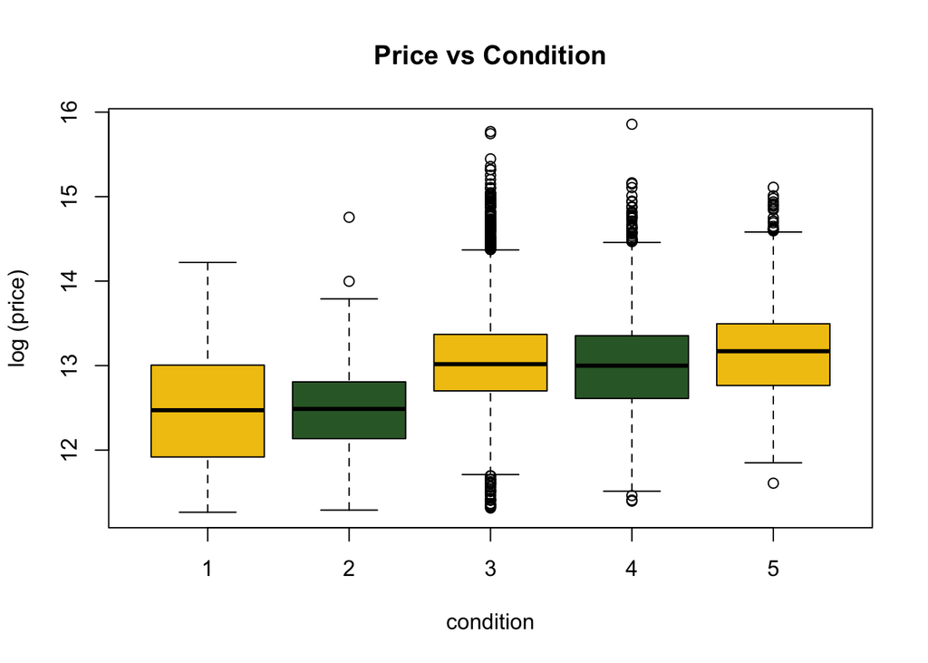

```r
graph8 <- boxplot(train2[, "logprice"] ~ train2[, "condition"],
                  main = "Price vs Condition", col=c("#F1C40F","#336633"),
                  xlab="condition", ylab="log (price)")
```

The relationship is linear.

### Boxplot between price and grade

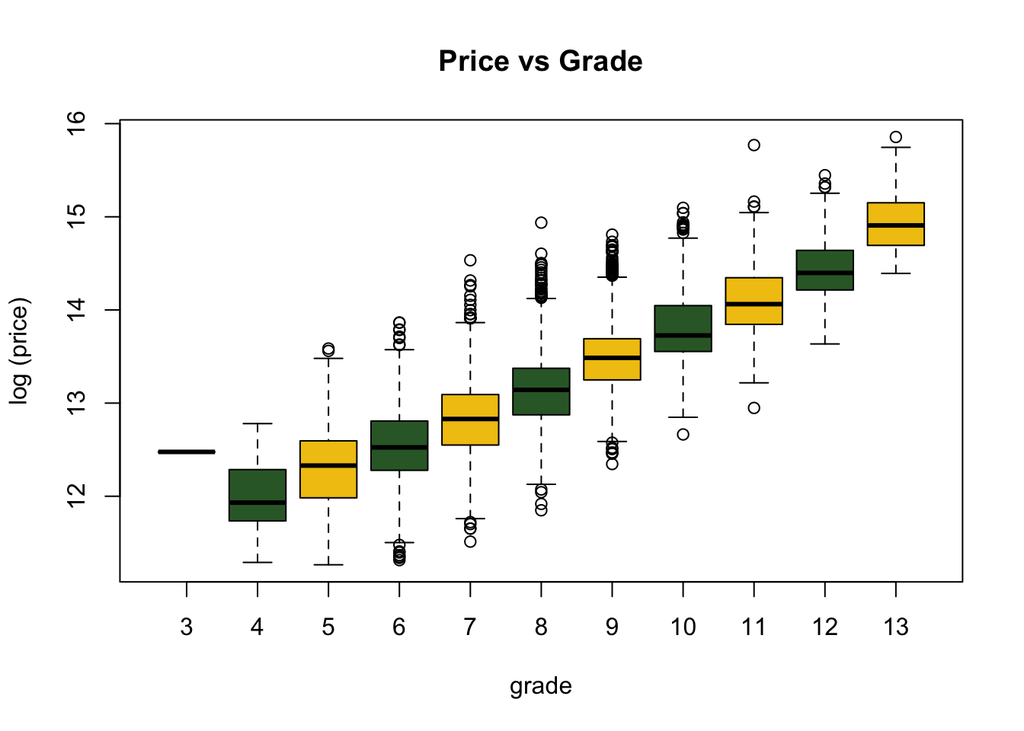

```r
graph9 <- boxplot(train2[, "logprice"] ~ train2[, "grade"],
                  main = "Price vs Grade", col=c("#F1C40F","#336633"),
                  xlab="grade", ylab="log (price)")
```

The relationship is linear.

### Boxplot between price and sqft_living

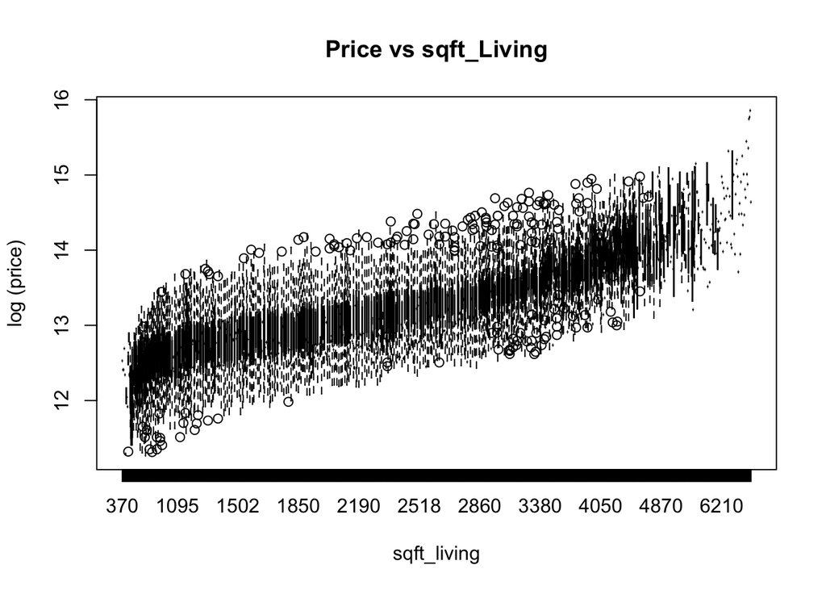

```r
graph10 <- boxplot(train2[, "logprice"] ~ train2[, "sqft_living"],
                  main = "Price vs sqft_Living", col=c("#F1C40F","#336633"),
                  xlab="sqft_living", ylab="log (price)")
```

The relationship looks linear. The bigger the living room, the higher the price of the house.

### Boxplot between price and sqft_basement

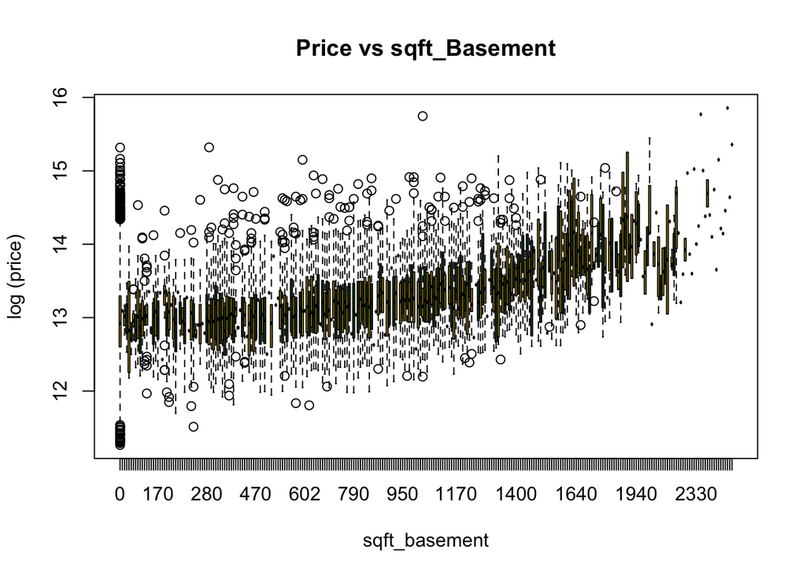

```r
graph11 <- boxplot(train2[, "logprice"] ~ train2[, "sqft_basement"],
                   main = "Price vs sqft_Basement", col=c("#F1C40F","#336633"),
                   xlab="sqft_basement", ylab="log (price)")
```

```r
length(train2$sqft_basement[train2$sqft_basement == 0])
```

```
## [1] 10521
```

```r
length(train2$sqft_basement[train2$sqft_basement != 0])
```

```
## [1] 6756
```

Therefore, I decided to simplify this field and make it a boolean: it will take value 0 if the house does not have a basement, and it will take value 1 if the house has a basement, no matter its size.

### Boxplot between price and yr_renovated

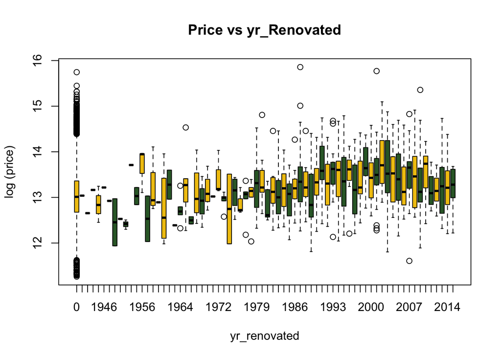

```r
graph12 <- boxplot(train2[, "logprice"] ~ train2[, "yr_renovated"],
                   main = "Price vs yr_Renovated", col=c("#F1C40F","#336633"),
                   xlab="yr_renovated", ylab="log (price)")
```

This graph is very similar to the previous one regarding the basement situation. As for having a basement or not, the same reasoning can be applied to the renovation of the house. It does not really matter when the house has been renovated, but what matters is if the house has been renovated at all.

```r
length(train2$yr_renovated[train2$yr_renovated == 0])
```

```
## [1] 16538
```

```r
length(train2$yr_renovated[train2$yr_renovated != 0])
```

```
## [1] 739
```

As we can see, most of the houses have not been renovated, so we will transform this field into boolean.

### Boxplot between price and zipcode

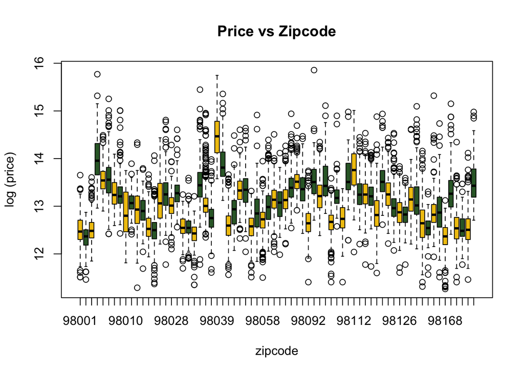

```r
graph13 <- boxplot(train2[, "logprice"] ~ train2[, "zipcode"],
                   main = "Price vs Zipcode", col=c("#F1C40F","#336633"),
                   xlab="zipcode", ylab="log (price)")
```

We can not really see a pattern in this graph, so we will categorize the variable when modelling (as predicted before).

### Boxplot between price and sqft_living15

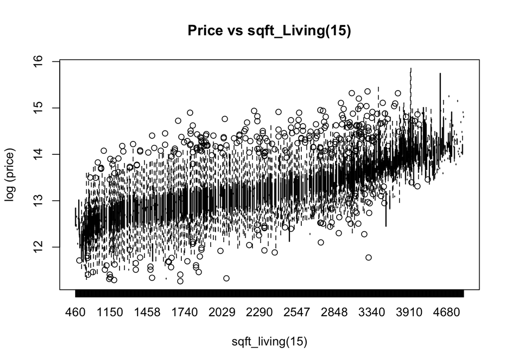

```r
graph14 <- boxplot(train2[, "logprice"] ~ train2[, "sqft_living15"],
                   main = "Price vs sqft_Living(15)", col=c("#F1C40F","#336633"),
                   xlab="sqft_living(15)", ylab="log (price)")
```

As for the variable *sqft_living*, we see a direct relationship in this graph. As the area of the living room increases, the price ofthe house increases as well.

Given all the insights from the data visualization section, we can proceed in apply the changes to our dataset.

First, as seen in the graph for the bathrooms, we eliminate the bathroom with value 7.5 because its price was odd and probably it was a mistake.

```r
train2 <- train2[-5419, ]
```

Then, as seen in the graph for the bedrooms, we only keep those house with 10 or less bedrooms, since the two houses with 11 and 33 bedrooms had wrong values for their price.

```r
train2 <- train2[train2$bedrooms <= 10, ]
```

We dummify the *sqft_basement* field, transforming all the houses with a basement with value 1, and keeping all the houses without a basement with value 0.

```r
train2$sqft_basement[train2$sqft_basement != 0] = 1
test2$sqft_basement[test2$sqft_basement != 0] = 1
```

We dummify the *yr_renovated* field, transforming all the houses that has been renovated with value 1, and keeping all the houses without renovation with value 0.

```r
train2$yr_renovated[train2$yr_renovated != 0] = 1
test2$yr_renovated[test2$yr_renovated != 0] = 1
```

Lastly, we stack back together the train and test set.

```r
train2$logprice <- NULL
complete2 <- Stack(train2, test2)
```